V3 · Website archive ↗

# NCAA Distance Performance, Climate, and Elevation EDA

This notebook analyzes how seasonal climate, elevation, and school context relate to NCAA distance performance across events and gender.

## Analysis Roadmap

1. Preliminary data analysis and baseline distributions
2. Seasonal climate relationships
3. Indoor vs outdoor standardized comparisons
4. Elevation effects
5. Athlete development and school context
6. Findings

# 1. Preliminary Data Analysis and Baseline Distributions

```python
import numpy as np
import pandas as pd
import seaborn as sns
import matplotlib.pyplot as plt
from matplotlib.ticker import FuncFormatter
from IPython.display import Markdown, display

sns.set_theme(style='whitegrid', context='talk')
pd.set_option('display.max_columns', 100)

data = pd.read_csv('tffrs_longitudinal_with_college_and_seasonal_weather.csv')
df = data.copy()

if 'Performance Seconds' in df.columns:
    df['Performance Seconds'] = pd.to_numeric(df['Performance Seconds'], errors='coerce')

def seconds_to_clock(x, pos=None):
    if pd.isna(x):
        return ''
    total = int(round(max(float(x), 0)))
    m, s = divmod(total, 60)
    h, m = divmod(m, 60)
    if h > 0:
        return f'{h}:{m:02d}:{s:02d}'
    return f'{m}:{s:02d}'
```

```python
# 1) Data Summary
summary = pd.DataFrame({
    'metric': ['rows', 'columns', 'unique schools', 'unique athletes', 'missing performance %'],
    'value': [
        len(df),
        df.shape[1],
        df['Athlete School'].nunique() if 'Athlete School' in df.columns else np.nan,
        df['Athlete Name'].nunique() if 'Athlete Name' in df.columns else np.nan,
        round(df['Performance Seconds'].isna().mean() * 100, 2) if 'Performance Seconds' in df.columns else np.nan,
    ],
})
display(summary)

display(df[['Event', 'Gender', 'Class', 'Performance Seconds', 'Avg_Winter_Temp_F', 'Avg_Spring_Temp_F']].head(8))
```

|  | metric | value |
| --- | --- | --- |
| 0 | rows | 36769.0 |
| 1 | columns | 21.0 |
| 2 | unique schools | 360.0 |
| 3 | unique athletes | 7265.0 |
| 4 | missing performance % | 0.0 |

|  | Event | Gender | Class | Performance Seconds | Avg_Winter_Temp_F | Avg_Spring_Temp_F |
| --- | --- | --- | --- | --- | --- | --- |
| 0 | 10k | Female | FR | 2509.53 | 49.708 | 64.358913 |
| 1 | 10k | Female | SO | 2318.03 | 49.708 | 64.358913 |
| 2 | 10k | Female | JR | 2235.57 | 49.708 | 64.358913 |
| 3 | 10k | Female | SO | 2047.87 | 46.610 | 58.951087 |
| 4 | 10k | Female | JR | 2151.51 | 46.610 | 58.951087 |
| 5 | 10k | Female | FR | 2908.24 | NaN | NaN |
| 6 | 10k | Female | SR | 2864.29 | NaN | NaN |
| 7 | 10k | Female | JR | 2040.15 | 48.552 | 59.798261 |

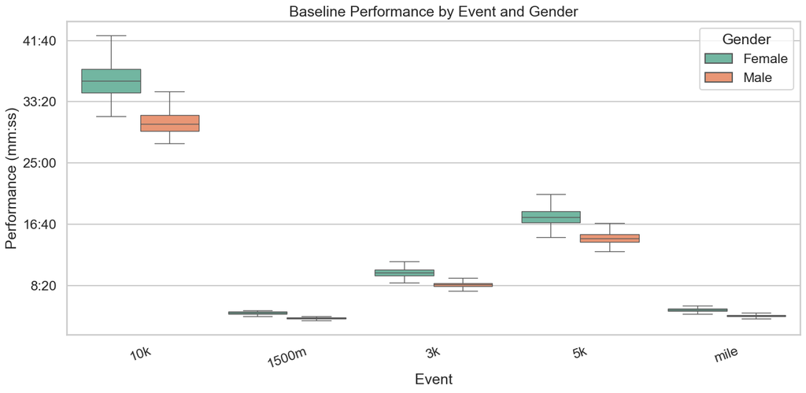

```python
# 2) Baseline performance distributions by event and gender.
from matplotlib.ticker import FuncFormatter

def _seconds_to_clock_local(x, pos=None):
    if pd.isna(x):
        return ''
    total = int(round(max(float(x), 0)))
    m, s = divmod(total, 60)
    h, m = divmod(m, 60)
    if h > 0:
        return f'{h}:{m:02d}:{s:02d}'
    return f'{m}:{s:02d}'

baseline = df.dropna(subset=['Performance Seconds', 'Event', 'Gender']).copy()

plt.figure(figsize=(14, 7))
sns.boxplot(
    data=baseline,
    x='Event',
    y='Performance Seconds',
    hue='Gender',
    showfliers=False,
    palette='Set2',
)
plt.title('Baseline Performance by Event and Gender')
plt.xlabel('Event')
plt.ylabel('Performance (mm:ss)')
plt.gca().yaxis.set_major_formatter(FuncFormatter(_seconds_to_clock_local))
plt.xticks(rotation=20)
plt.tight_layout()
plt.show()
```

### Baseline Performance Profile

This section establishes reference performance distributions across events and gender before climate and elevation adjustments.

```python
# 2) Baseline context tables for interpretation
event_gender_counts = (
    df.groupby(['Event', 'Gender'], as_index=False)['Performance Seconds']
    .count()
    .rename(columns={'Performance Seconds': 'n_records'})
)
display(event_gender_counts.sort_values(['Event', 'Gender']))

class_counts = (
    df.dropna(subset=['Class'])
    .groupby(['Class', 'Gender'], as_index=False)['Performance Seconds']
    .count()
    .rename(columns={'Performance Seconds': 'n_records'})
)
display(class_counts.sort_values(['Class', 'Gender']))
```

|  | Event | Gender | n_records |
| --- | --- | --- | --- |
| 0 | 10k | Female | 1127 |
| 1 | 10k | Male | 1387 |
| 2 | 1500m | Female | 4462 |
| 3 | 1500m | Male | 4211 |
| 4 | 3k | Female | 3799 |
| 5 | 3k | Male | 3815 |
| 6 | 5k | Female | 5347 |
| 7 | 5k | Male | 5490 |
| 8 | mile | Female | 3604 |
| 9 | mile | Male | 3527 |

|  | Class | Gender | n_records |
| --- | --- | --- | --- |
| 0 | FR | Female | 4173 |
| 1 | FR | Male | 4221 |
| 2 | JR | Female | 5208 |
| 3 | JR | Male | 5202 |
| 4 | SO | Female | 5745 |
| 5 | SO | Male | 5812 |
| 6 | SR | Female | 3213 |
| 7 | SR | Male | 3195 |

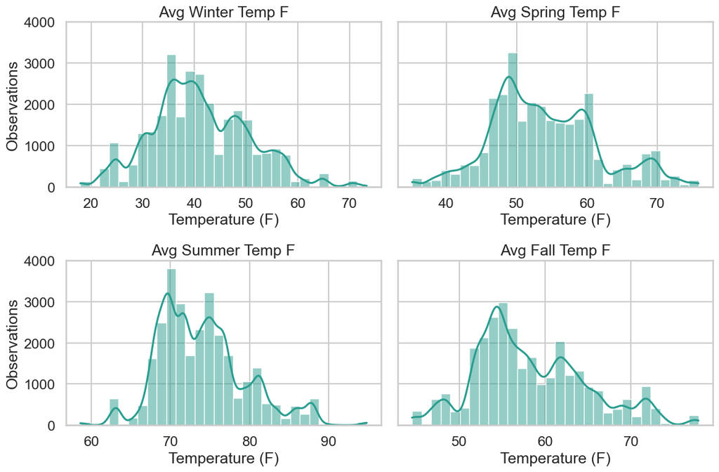

```python
# 3) Seasonal temperature distributions.
season_cols = ['Avg_Winter_Temp_F', 'Avg_Spring_Temp_F', 'Avg_Summer_Temp_F', 'Avg_Fall_Temp_F']
fig, axes = plt.subplots(2, 2, figsize=(12, 8), sharey=True)

for ax, col in zip(axes.flat, season_cols):
    vals = df[col].dropna()
    sns.histplot(vals, bins=30, kde=True, color='#2A9D8F', ax=ax)
    ax.set_title(col.replace('_', ' '))
    ax.set_xlabel('Temperature (F)')
    ax.set_ylabel('Observations')

plt.tight_layout()
plt.show()
```

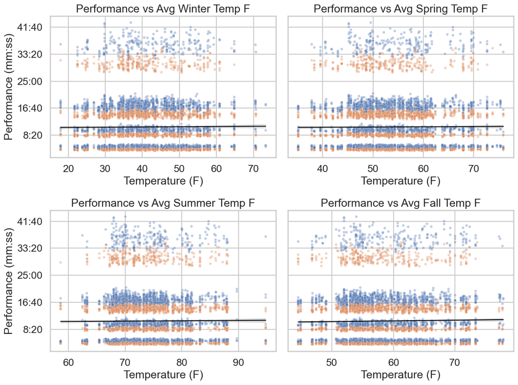

```python
# 4) Relationship between seasonal temps and performance (sampled for readability).
rel = df.dropna(subset=['Performance Seconds', 'Gender', 'Avg_Winter_Temp_F', 'Avg_Spring_Temp_F', 'Avg_Summer_Temp_F', 'Avg_Fall_Temp_F']).copy()
if len(rel) > 8000:
    rel = rel.sample(8000, random_state=42)

fig, axes = plt.subplots(2, 2, figsize=(12, 9), sharey=True)
for ax, col in zip(axes.flat, ['Avg_Winter_Temp_F', 'Avg_Spring_Temp_F', 'Avg_Summer_Temp_F', 'Avg_Fall_Temp_F']):
    sns.scatterplot(
        data=rel,
        x=col,
        y='Performance Seconds',
        hue='Gender',
        alpha=0.35,
        s=18,
        ax=ax,
        legend=False,
    )
    sns.regplot(
        data=rel,
        x=col,
        y='Performance Seconds',
        scatter=False,
        color='black',
        line_kws={'linewidth': 1.4},
        ax=ax,
    )
    ax.set_title(f'Performance vs {col.replace("_", " ")}')
    ax.set_xlabel('Temperature (F)')
    ax.set_ylabel('Performance (mm:ss)')
    ax.yaxis.set_major_formatter(FuncFormatter(seconds_to_clock))

plt.tight_layout()
plt.show()
```

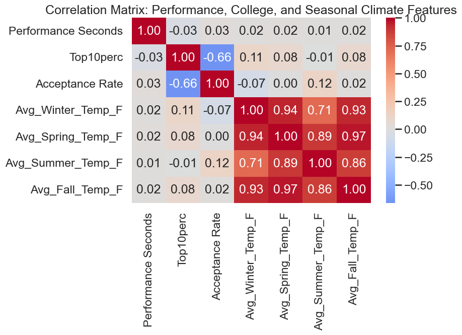

```python
# 5) Correlation heatmap of weather + admissions + performance.
heat_cols = [
    'Performance Seconds',
    'Top10perc',
    'Acceptance Rate',
    'Avg_Winter_Temp_F',
    'Avg_Spring_Temp_F',
    'Avg_Summer_Temp_F',
    'Avg_Fall_Temp_F',
]
heat_df = df[heat_cols].dropna()

corr = heat_df.corr(numeric_only=True)
fig, ax = plt.subplots(figsize=(9, 7))
sns.heatmap(corr, annot=True, fmt='.2f', cmap='coolwarm', center=0, ax=ax)
ax.set_title('Correlation Matrix: Performance, College, and Seasonal Climate Features')
plt.tight_layout()
plt.show()
```

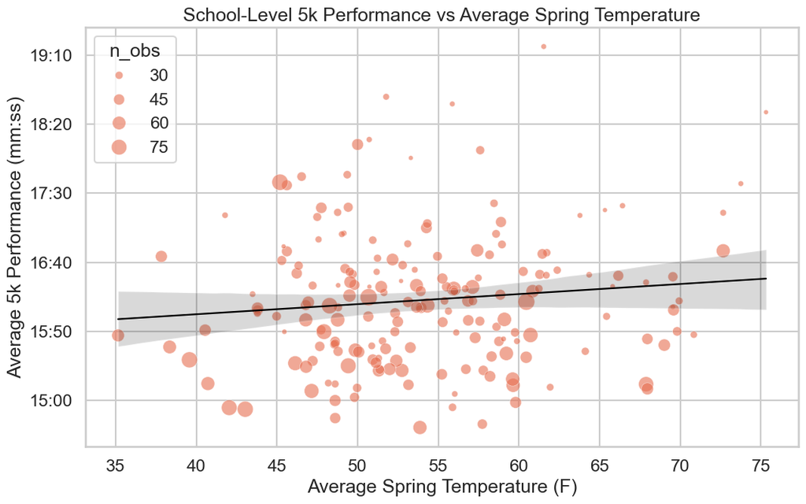

```python
# 6) School-level comparison: avg 5k performance vs avg spring temp.
school_event = df[(df['Event'] == '5k') & df['Performance Seconds'].notna() & df['Avg_Spring_Temp_F'].notna()].copy()
school_summary = (
    school_event.groupby('Athlete School', observed=True)
    .agg(
        avg_5k_seconds=('Performance Seconds', 'mean'),
        avg_spring_f=('Avg_Spring_Temp_F', 'mean'),
        n_obs=('Performance Seconds', 'size')
    )
    .reset_index()
)
school_summary = school_summary[school_summary['n_obs'] >= 20]

fig, ax = plt.subplots(figsize=(11, 7))
sns.scatterplot(
    data=school_summary,
    x='avg_spring_f',
    y='avg_5k_seconds',
    size='n_obs',
    sizes=(20, 260),
    alpha=0.6,
    color='#E76F51',
    ax=ax,
)
sns.regplot(
    data=school_summary,
    x='avg_spring_f',
    y='avg_5k_seconds',
    scatter=False,
    color='black',
    line_kws={'linewidth': 1.6},
    ax=ax,
)
ax.set_title('School-Level 5k Performance vs Average Spring Temperature')
ax.set_xlabel('Average Spring Temperature (F)')
ax.set_ylabel('Average 5k Performance (mm:ss)')
ax.yaxis.set_major_formatter(FuncFormatter(seconds_to_clock))
plt.tight_layout()
plt.show()
```

# 2. Seasonal Climate Relationships

This section tests whether school-level seasonal temperatures align with systematic differences in performance.

```python
# Indoor vs outdoor analysis prep (true season labels from raw results).
raw = pd.read_csv('tfrrs_all_distance_events_one_csv.csv')
seasonal_school = pd.read_csv('school_climates_seasonal.csv')

raw = raw.merge(seasonal_school, on='Athlete School', how='left')

# Parse time strings into seconds.
def time_to_seconds(x):
    if pd.isna(x):
        return np.nan
    s = str(x).strip().replace('@', '')
    parts = s.split(':')
    try:
        if len(parts) == 1:
            return float(parts[0])
        if len(parts) == 2:
            return int(parts[0]) * 60 + float(parts[1])
        if len(parts) == 3:
            return int(parts[0]) * 3600 + int(parts[1]) * 60 + float(parts[2])
    except Exception:
        return np.nan
    return np.nan

raw['Performance Seconds'] = raw['Performance Time'].apply(time_to_seconds)
raw['SeasonStd'] = raw['Season'].astype(str).str.strip().str.lower().map({'indoor': 'Indoor', 'outdoor': 'Outdoor'})
raw = raw.dropna(subset=['Performance Seconds', 'Gender', 'Event', 'SeasonStd'])

# Standardize within Event x Gender x Season to compare performance across events.
group_stats = (
    raw.groupby(['Event', 'Gender', 'SeasonStd'], observed=True)['Performance Seconds']
    .agg(['mean', 'std'])
    .reset_index()
)
raw = raw.merge(group_stats, on=['Event', 'Gender', 'SeasonStd'], how='left')
raw['Performance Z'] = (raw['Performance Seconds'] - raw['mean']) / raw['std']
raw = raw.replace([np.inf, -np.inf], np.nan)

print(f'Rows ready for seasonal analysis: {len(raw):,}')
raw[['Season', 'SeasonStd', 'Event', 'Gender', 'Performance Seconds', 'Performance Z']].head()
```

```
Rows ready for seasonal analysis: 70,781
```

|  | Season | SeasonStd | Event | Gender | Performance Seconds | Performance Z |
| --- | --- | --- | --- | --- | --- | --- |
| 0 | indoor | Indoor | mile | Male | 232.03 | -2.369559 |
| 1 | indoor | Indoor | mile | Male | 233.36 | -2.232563 |
| 2 | indoor | Indoor | mile | Male | 234.07 | -2.159430 |
| 3 | indoor | Indoor | mile | Male | 234.36 | -2.129558 |
| 4 | indoor | Indoor | mile | Male | 234.46 | -2.119258 |

# 3. Indoor vs Outdoor Standardized Comparisons

Raw times differ by event and gender scale, so this section uses within-group z-scores for fairer comparisons.

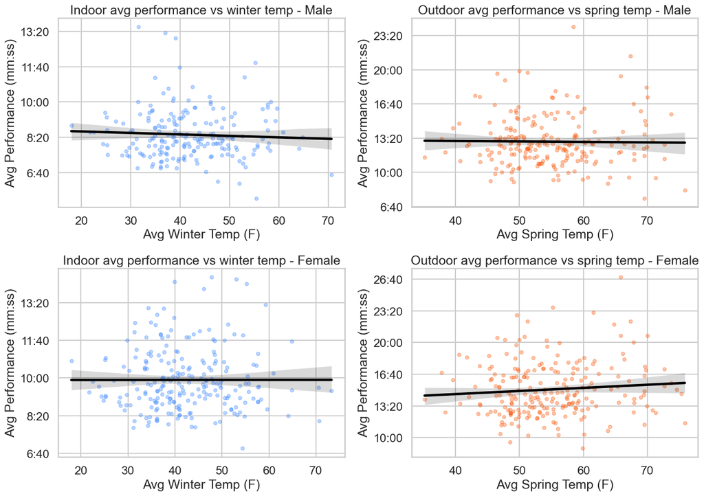

```python
# Chart 3: School-level indoor/outdoor relationship with climate (men/women split).
school_season = (
    raw[raw['SeasonStd'].isin(['Indoor', 'Outdoor'])]
    .groupby(['Athlete School', 'Gender', 'SeasonStd'], observed=True)
    .agg(
        avg_perf=('Performance Seconds', 'mean'),
        avg_winter_f=('Avg_Winter_Temp_F', 'mean'),
        avg_spring_f=('Avg_Spring_Temp_F', 'mean'),
        n=('Performance Seconds', 'size'),
    )
    .reset_index()
)

fig, axes = plt.subplots(2, 2, figsize=(14, 10), sharey=False)
for r, gender in enumerate(['Male', 'Female']):
    g = school_season[(school_season['Gender'] == gender) & (school_season['n'] >= 8)]

    gi = g[g['SeasonStd'] == 'Indoor']
    sns.regplot(data=gi, x='avg_winter_f', y='avg_perf', scatter_kws={'alpha':0.35, 's':24}, line_kws={'color':'black'}, color='#3A86FF', ax=axes[r,0])
    axes[r,0].set_title(f'Indoor avg performance vs winter temp - {gender}')
    axes[r,0].set_xlabel('Avg Winter Temp (F)')
    axes[r,0].set_ylabel('Avg Performance (mm:ss)')
    axes[r,0].yaxis.set_major_formatter(FuncFormatter(seconds_to_clock))

    go = g[g['SeasonStd'] == 'Outdoor']
    sns.regplot(data=go, x='avg_spring_f', y='avg_perf', scatter_kws={'alpha':0.35, 's':24}, line_kws={'color':'black'}, color='#FB5607', ax=axes[r,1])
    axes[r,1].set_title(f'Outdoor avg performance vs spring temp - {gender}')
    axes[r,1].set_xlabel('Avg Spring Temp (F)')
    axes[r,1].set_ylabel('Avg Performance (mm:ss)')
    axes[r,1].yaxis.set_major_formatter(FuncFormatter(seconds_to_clock))

plt.tight_layout()
plt.show()
```

# 4. Elevation Effects

This section explores how altitude context relates to standardized and raw performance outcomes.

```python
# Prep: Load elevation data and merge into raw data with quartile binning
# Load elevation data from school_climates.csv
elevation_school = pd.read_csv('school_climates.csv')[['Athlete School', 'Elevation_Feet']].drop_duplicates()

# Merge elevation into raw
raw_elev = raw.merge(elevation_school, on='Athlete School', how='left')

# Create quartile bins based on percentiles (handle duplicates)
print(f"Rows with elevation data: {raw_elev['Elevation_Feet'].notna().sum()} / {len(raw_elev)}")
print(f"Elevation range: {raw_elev['Elevation_Feet'].min():.0f} - {raw_elev['Elevation_Feet'].max():.0f} feet")
print(f"\nElevation quartiles:")
print(raw_elev['Elevation_Feet'].quantile([0.25, 0.5, 0.75]))

# Rank-based quartile mapping for robustness
elev_clean = raw_elev.dropna(subset=['Elevation_Feet'])
q_labels_elev = ['Q1 (Low)', 'Q2 (Mid-Low)', 'Q3 (Mid-High)', 'Q4 (High)']
elev_clean['Elevation_Quartile'] = pd.cut(
    elev_clean['Elevation_Feet'].rank(method='average', pct=True),
    bins=[0, 0.25, 0.5, 0.75, 1.0],
    labels=q_labels_elev
)
raw_elev = raw_elev.merge(
    elev_clean[['Athlete School', 'Elevation_Quartile']].drop_duplicates(),
    on='Athlete School',
    how='left'
)

print(f"\nElevation quartile counts:\n{raw_elev['Elevation_Quartile'].value_counts().sort_index()}")
```

```
Rows with elevation data: 67048 / 70781
Elevation range: -59 - 7795 feet

Elevation quartiles:
0.25    183.72704
0.50    606.95540
0.75    938.32024
Name: Elevation_Feet, dtype: float64

Elevation quartile counts:
Elevation_Quartile
Q1 (Low)         16756
Q2 (Mid-Low)     16917
Q3 (Mid-High)    16579
Q4 (High)        16796
Name: count, dtype: int64
```

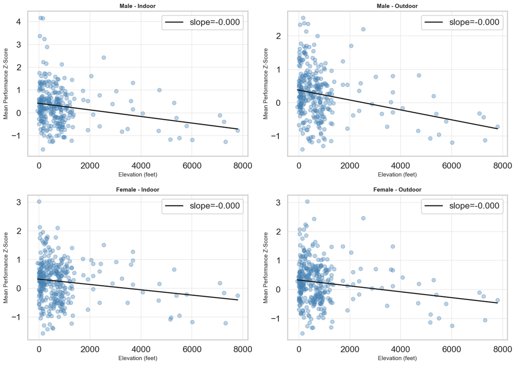

```python
# Chart 3: School-level performance vs elevation (by gender x environment, scatter+regression)
school_elev = raw_elev.groupby(['Athlete School', 'Gender', 'SeasonStd']).agg({
    'Performance Z': 'mean',
    'Elevation_Feet': 'first'
}).reset_index().dropna()

fig, axes = plt.subplots(2, 2, figsize=(14, 10))
axes = axes.flatten()
plot_idx = 0

for gender in ['Male', 'Female']:
    for season in ['Indoor', 'Outdoor']:
        data = school_elev[(school_elev['Gender'] == gender) & (school_elev['SeasonStd'] == season)]
        if len(data) > 5:
            ax = axes[plot_idx]
            ax.scatter(data['Elevation_Feet'], data['Performance Z'], alpha=0.35, s=50, color='steelblue')

            # Regression line
            z_fit = np.polyfit(data['Elevation_Feet'], data['Performance Z'], 1)
            p = np.poly1d(z_fit)
            x_range = np.linspace(data['Elevation_Feet'].min(), data['Elevation_Feet'].max(), 100)
            ax.plot(x_range, p(x_range), 'k-', linewidth=2, label=f'slope={z_fit[0]:.3f}')

            ax.set_xlabel('Elevation (feet)', fontsize=11)
            ax.set_ylabel('Mean Performance Z-Score', fontsize=11)
            ax.set_title(f'{gender} - {season}', fontsize=11, fontweight='bold')
            ax.grid(alpha=0.3)
            ax.legend()
            plot_idx += 1

plt.tight_layout()
plt.show()
```

## Time vs Elevation by Event (Raw Times)

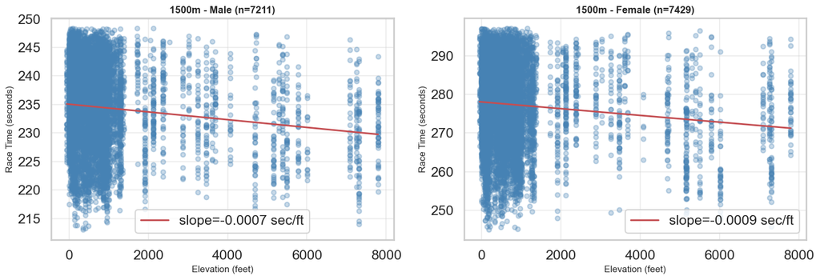

```
1500m data: Male=7211, Female=7429
```

```python
# 1500m: Time vs Elevation by Gender
data_1500 = raw_elev[raw_elev['Event'] == '1500m'].dropna(subset=['Performance Seconds', 'Elevation_Feet'])

fig, axes = plt.subplots(1, 2, figsize=(14, 5))

for i, gender in enumerate(['Male', 'Female']):
    data_gender = data_1500[data_1500['Gender'] == gender]
    ax = axes[i]

    ax.scatter(data_gender['Elevation_Feet'], data_gender['Performance Seconds'], alpha=0.3, s=30, color='steelblue')

    # Regression line with error handling
    if len(data_gender) > 10:
        try:
            z_fit = np.polyfit(data_gender['Elevation_Feet'], data_gender['Performance Seconds'], 1)
            p = np.poly1d(z_fit)
            x_range = np.linspace(data_gender['Elevation_Feet'].min(), data_gender['Elevation_Feet'].max(), 100)
            ax.plot(x_range, p(x_range), 'r-', linewidth=2, label=f'slope={z_fit[0]:.4f} sec/ft')
            ax.legend()
        except:
            pass

    ax.set_xlabel('Elevation (feet)', fontsize=11)
    ax.set_ylabel('Race Time (seconds)', fontsize=11)
    ax.set_title(f'1500m - {gender} (n={len(data_gender)})', fontsize=12, fontweight='bold')
    ax.grid(alpha=0.3)

plt.tight_layout()
plt.show()

print(f"1500m data: Male={len(data_1500[data_1500['Gender']=='Male'])}, Female={len(data_1500[data_1500['Gender']=='Female'])}")
```

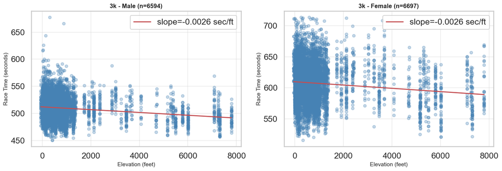

```
3k data: Male=6594, Female=6697
```

```python
# 3k: Time vs Elevation by Gender
data_3k = raw_elev[raw_elev['Event'] == '3k'].dropna(subset=['Performance Seconds', 'Elevation_Feet'])

fig, axes = plt.subplots(1, 2, figsize=(14, 5))

for i, gender in enumerate(['Male', 'Female']):
    data_gender = data_3k[data_3k['Gender'] == gender]
    ax = axes[i]

    ax.scatter(data_gender['Elevation_Feet'], data_gender['Performance Seconds'], alpha=0.3, s=30, color='steelblue')

    # Regression line with error handling
    if len(data_gender) > 10:
        try:
            z_fit = np.polyfit(data_gender['Elevation_Feet'], data_gender['Performance Seconds'], 1)
            p = np.poly1d(z_fit)
            x_range = np.linspace(data_gender['Elevation_Feet'].min(), data_gender['Elevation_Feet'].max(), 100)
            ax.plot(x_range, p(x_range), 'r-', linewidth=2, label=f'slope={z_fit[0]:.4f} sec/ft')
            ax.legend()
        except:
            pass

    ax.set_xlabel('Elevation (feet)', fontsize=11)
    ax.set_ylabel('Race Time (seconds)', fontsize=11)
    ax.set_title(f'3k - {gender} (n={len(data_gender)})', fontsize=12, fontweight='bold')
    ax.grid(alpha=0.3)

plt.tight_layout()
plt.show()

print(f"3k data: Male={len(data_3k[data_3k['Gender']=='Male'])}, Female={len(data_3k[data_3k['Gender']=='Female'])}")
```

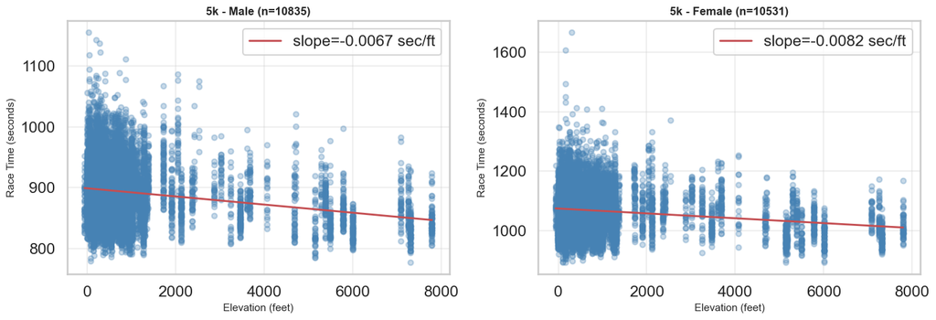

```
5k data: Male=10835, Female=10531
```

```python
# 5k: Time vs Elevation by Gender
data_5k = raw_elev[raw_elev['Event'] == '5k'].dropna(subset=['Performance Seconds', 'Elevation_Feet'])

fig, axes = plt.subplots(1, 2, figsize=(14, 5))

for i, gender in enumerate(['Male', 'Female']):
    data_gender = data_5k[data_5k['Gender'] == gender]
    ax = axes[i]

    ax.scatter(data_gender['Elevation_Feet'], data_gender['Performance Seconds'], alpha=0.3, s=30, color='steelblue')

    # Regression line with error handling
    if len(data_gender) > 10:
        try:
            z_fit = np.polyfit(data_gender['Elevation_Feet'], data_gender['Performance Seconds'], 1)
            p = np.poly1d(z_fit)
            x_range = np.linspace(data_gender['Elevation_Feet'].min(), data_gender['Elevation_Feet'].max(), 100)
            ax.plot(x_range, p(x_range), 'r-', linewidth=2, label=f'slope={z_fit[0]:.4f} sec/ft')
            ax.legend()
        except:
            pass

    ax.set_xlabel('Elevation (feet)', fontsize=11)
    ax.set_ylabel('Race Time (seconds)', fontsize=11)
    ax.set_title(f'5k - {gender} (n={len(data_gender)})', fontsize=12, fontweight='bold')
    ax.grid(alpha=0.3)

plt.tight_layout()
plt.show()

print(f"5k data: Male={len(data_5k[data_5k['Gender']=='Male'])}, Female={len(data_5k[data_5k['Gender']=='Female'])}")
```

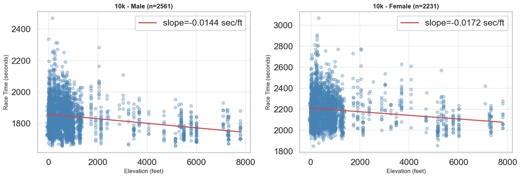

```
10k data: Male=2561, Female=2231
```

```python
# 10k: Time vs Elevation by Gender
data_10k = raw_elev[raw_elev['Event'] == '10k'].dropna(subset=['Performance Seconds', 'Elevation_Feet'])

fig, axes = plt.subplots(1, 2, figsize=(14, 5))

for i, gender in enumerate(['Male', 'Female']):
    data_gender = data_10k[data_10k['Gender'] == gender]
    ax = axes[i]

    ax.scatter(data_gender['Elevation_Feet'], data_gender['Performance Seconds'], alpha=0.3, s=30, color='steelblue')

    # Regression line with error handling
    if len(data_gender) > 10:
        try:
            z_fit = np.polyfit(data_gender['Elevation_Feet'], data_gender['Performance Seconds'], 1)
            p = np.poly1d(z_fit)
            x_range = np.linspace(data_gender['Elevation_Feet'].min(), data_gender['Elevation_Feet'].max(), 100)
            ax.plot(x_range, p(x_range), 'r-', linewidth=2, label=f'slope={z_fit[0]:.4f} sec/ft')
            ax.legend()
        except:
            pass

    ax.set_xlabel('Elevation (feet)', fontsize=11)
    ax.set_ylabel('Race Time (seconds)', fontsize=11)
    ax.set_title(f'10k - {gender} (n={len(data_gender)})', fontsize=12, fontweight='bold')
    ax.grid(alpha=0.3)

plt.tight_layout()
plt.show()

print(f"10k data: Male={len(data_10k[data_10k['Gender']=='Male'])}, Female={len(data_10k[data_10k['Gender']=='Female'])}")
```

# 5. Athlete Development and School Context

This section quantifies year-over-year athlete progression and tests whether school selectivity, elevation, and seasonal temperature align with development patterns.

```python
# 5) Athlete improvement modeling dataset
long_df = pd.read_csv('tffrs_longitudinal_with_college_and_seasonal_weather.csv')

elev_df = pd.read_csv('school_climates.csv')[['Athlete School', 'Elevation_Feet']].drop_duplicates()
long_df = long_df.merge(elev_df, on='Athlete School', how='left')

class_order = {'FR': 0, 'SO': 1, 'JR': 2, 'SR': 3}
long_df['Class_Num'] = long_df['Class'].map(class_order)

long_df['Performance Seconds'] = pd.to_numeric(long_df['Performance Seconds'], errors='coerce')
long_df = long_df.dropna(subset=['Class_Num', 'Performance Seconds'])

improvement_rows = []
group_cols = ['Athlete Name', 'Athlete School', 'Gender', 'Event']
for keys, group in long_df.groupby(group_cols, observed=True):
    group = group.sort_values('Class_Num')
    first = group.iloc[0]
    last = group.iloc[-1]
    class_span = last['Class_Num'] - first['Class_Num']
    if class_span <= 0:
        continue

    improvement_secs = first['Performance Seconds'] - last['Performance Seconds']
    improvement_rows.append({
        'Athlete Name': keys[0],
        'Athlete School': keys[1],
        'Gender': keys[2],
        'Event': keys[3],
        'Improvement_Secs': improvement_secs,
        'Improvement_Per_Year': improvement_secs / class_span,
        'N_Classes': group['Class_Num'].nunique(),
        'Elevation_Feet': first.get('Elevation_Feet', np.nan),
        'Avg_Winter_Temp_F': first.get('Avg_Winter_Temp_F', np.nan),
        'Avg_Spring_Temp_F': first.get('Avg_Spring_Temp_F', np.nan),
        'Avg_Summer_Temp_F': first.get('Avg_Summer_Temp_F', np.nan),
        'Avg_Fall_Temp_F': first.get('Avg_Fall_Temp_F', np.nan),
        'Acceptance_Rate': first.get('Acceptance Rate', np.nan),
        'Top10perc': first.get('Top10perc', np.nan),
    })

improvement_df = pd.DataFrame(improvement_rows)
improvement_df = improvement_df.dropna(subset=['Improvement_Secs', 'Acceptance_Rate', 'Elevation_Feet'])

improvement_df['Accept_Quartile'] = pd.qcut(
    improvement_df['Acceptance_Rate'].rank(method='average', pct=True),
    q=4,
    labels=['Q1 (Most Selective)', 'Q2', 'Q3', 'Q4 (Least Selective)']
 )
improvement_df['Elev_Quartile'] = pd.qcut(
    improvement_df['Elevation_Feet'].rank(method='average', pct=True),
    q=4,
    labels=['Q1 (Low)', 'Q2', 'Q3', 'Q4 (High)']
 )

print(f"Athlete-event trajectories: {len(improvement_df):,}")
print(f"Schools represented: {improvement_df['Athlete School'].nunique():,}")
print(f"Mean improvement: {improvement_df['Improvement_Secs'].mean():.2f} sec")
display(improvement_df[['Event', 'Gender', 'Improvement_Per_Year', 'Accept_Quartile', 'Elev_Quartile']].head(10))
```

```
Athlete-event trajectories: 7,105
Schools represented: 151
Mean improvement: 8.63 sec
```

|  | Event | Gender | Improvement_Per_Year | Accept_Quartile | Elev_Quartile |
| --- | --- | --- | --- | --- | --- |
| 6 | 1500m | Female | 2.495 | Q2 | Q1 (Low) |
| 7 | mile | Female | 3.505 | Q2 | Q1 (Low) |
| 9 | 3k | Male | -0.720 | Q4 (Least Selective) | Q2 |
| 10 | 5k | Male | 11.060 | Q4 (Least Selective) | Q2 |
| 23 | 1500m | Female | 4.580 | Q2 | Q1 (Low) |
| 24 | mile | Female | 0.830 | Q2 | Q1 (Low) |
| 25 | 5k | Male | 20.850 | Q1 (Most Selective) | Q1 (Low) |
| 28 | 1500m | Male | 1.100 | Q1 (Most Selective) | Q1 (Low) |
| 29 | mile | Male | -3.285 | Q1 (Most Selective) | Q1 (Low) |
| 30 | 5k | Female | -6.780 | Q1 (Most Selective) | Q1 (Low) |

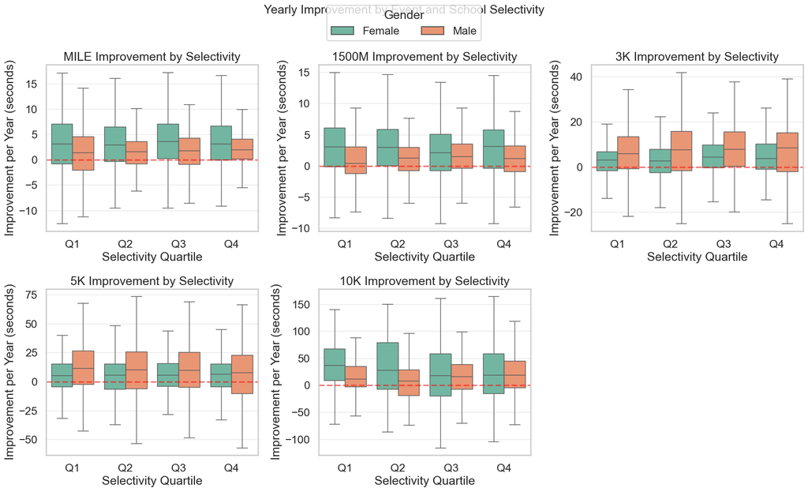

```
Quartiles: Q1 = most selective schools, Q4 = least selective schools
```

| Accept_Quartile | mean | median | count |
| --- | --- | --- | --- |
| Q1 (Most Selective) | 6.036665 | 3.440000 | 1823 |
| Q2 | 5.507882 | 2.970000 | 1759 |
| Q3 | 6.234547 | 3.665000 | 1792 |
| Q4 (Least Selective) | 5.723674 | 3.413333 | 1731 |

```python
# Improvement by school selectivity across events
events = ['mile', '1500m', '3k', '5k', '10k']
plot_df = improvement_df.copy()
plot_df['Accept_Quartile_Short'] = plot_df['Accept_Quartile'].map({
    'Q1 (Most Selective)': 'Q1',
    'Q2': 'Q2',
    'Q3': 'Q3',
    'Q4 (Least Selective)': 'Q4',
})

fig, axes = plt.subplots(2, 3, figsize=(17, 10), sharey=False)
axes = axes.flatten()

for idx, event in enumerate(events):
    ax = axes[idx]
    event_data = plot_df[(plot_df['Event'] == event) & plot_df['Accept_Quartile_Short'].notna()]
    if len(event_data) < 20:
        ax.axis('off')
        continue

    sns.boxplot(
        data=event_data,
        x='Accept_Quartile_Short',
        y='Improvement_Per_Year',
        hue='Gender',
        palette='Set2',
        ax=ax,
        showfliers=False,
    )
    ax.set_title(f'{event.upper()} Improvement by Selectivity')
    ax.set_xlabel('Selectivity Quartile')
    ax.set_ylabel('Improvement per Year (seconds)')
    ax.axhline(0, color='red', linestyle='--', alpha=0.5)
    ax.grid(axis='y', alpha=0.3)
    if ax.get_legend() is not None:
        ax.get_legend().remove()

if len(axes) > len(events):
    axes[-1].axis('off')

handles, labels = axes[0].get_legend_handles_labels()
fig.legend(handles, labels, loc='upper center', ncol=2, frameon=True, title='Gender')
fig.suptitle('Yearly Improvement by Event and School Selectivity', y=1.02, fontsize=18)
plt.tight_layout()
plt.show()

print('Quartiles: Q1 = most selective schools, Q4 = least selective schools')
display(plot_df.groupby('Accept_Quartile', observed=True)['Improvement_Per_Year'].agg(['mean', 'median', 'count']).sort_index())
```

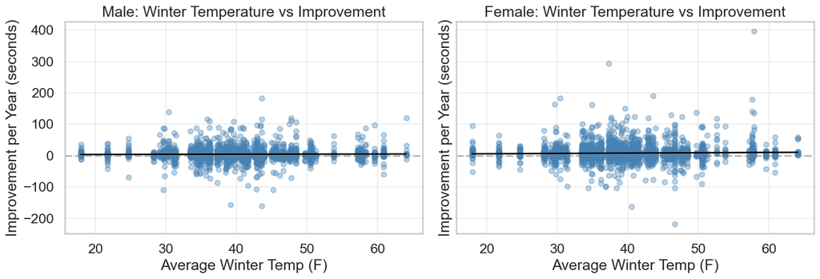

```
Winter temperature correlation with yearly improvement:
  Overall: +0.0239
  Male:    +0.0156
  Female:  +0.0328
```

```python
# Improvement vs winter temperature
fig, axes = plt.subplots(1, 2, figsize=(14, 5), sharey=True)

for i, gender in enumerate(['Male', 'Female']):
    ax = axes[i]
    gender_data = improvement_df[improvement_df['Gender'] == gender].dropna(subset=['Avg_Winter_Temp_F', 'Improvement_Per_Year'])

    ax.scatter(
        gender_data['Avg_Winter_Temp_F'],
        gender_data['Improvement_Per_Year'],
        alpha=0.35,
        s=36,
        color='steelblue',
    )

    if len(gender_data) > 10:
        sns.regplot(
            data=gender_data,
            x='Avg_Winter_Temp_F',
            y='Improvement_Per_Year',
            scatter=False,
            color='black',
            line_kws={'linewidth': 1.8},
            ax=ax,
        )

    ax.set_xlabel('Average Winter Temp (F)')
    ax.set_ylabel('Improvement per Year (seconds)')
    ax.set_title(f'{gender}: Winter Temperature vs Improvement')
    ax.axhline(0, color='gray', linestyle='--', alpha=0.5)
    ax.grid(alpha=0.3)

plt.tight_layout()
plt.show()

print('Winter temperature correlation with yearly improvement:')
overall_corr = improvement_df[['Avg_Winter_Temp_F', 'Improvement_Per_Year']].corr().iloc[0, 1]
male_corr = improvement_df[improvement_df['Gender'] == 'Male'][['Avg_Winter_Temp_F', 'Improvement_Per_Year']].corr().iloc[0, 1]
female_corr = improvement_df[improvement_df['Gender'] == 'Female'][['Avg_Winter_Temp_F', 'Improvement_Per_Year']].corr().iloc[0, 1]
print(f'  Overall: {overall_corr:+.4f}')
print(f'  Male:    {male_corr:+.4f}')
print(f'  Female:  {female_corr:+.4f}')
```

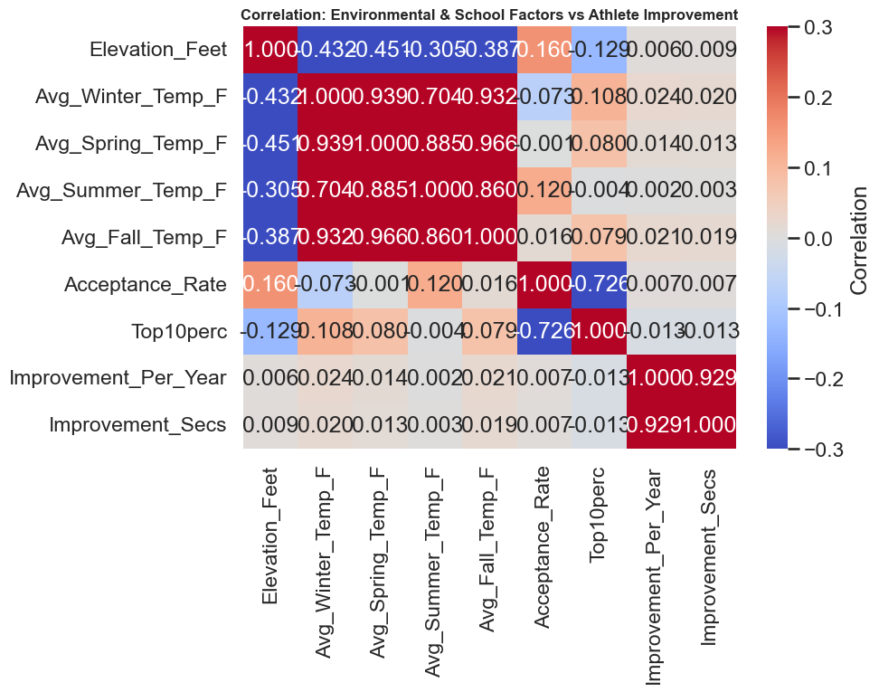

```
Correlation with Improvement per Year (sorted by magnitude):
  Avg_Winter_Temp_F        : +0.0239
  Avg_Fall_Temp_F          : +0.0214
  Avg_Spring_Temp_F        : +0.0144
  Top10perc                : -0.0126
  Acceptance_Rate          : +0.0074
  Elevation_Feet           : +0.0058
  Avg_Summer_Temp_F        : +0.0023
```

```python
# Correlation heatmap: Environmental features vs Improvement
feature_cols = [
    'Elevation_Feet', 'Avg_Winter_Temp_F', 'Avg_Spring_Temp_F',
    'Avg_Summer_Temp_F', 'Avg_Fall_Temp_F', 'Acceptance_Rate', 'Top10perc'
]

corr_data = improvement_df[feature_cols + ['Improvement_Per_Year', 'Improvement_Secs']].corr()

fig, ax = plt.subplots(figsize=(10, 8))
sns.heatmap(corr_data, annot=True, fmt='.3f', cmap='coolwarm', center=0,
           cbar_kws={'label': 'Correlation'}, ax=ax, vmin=-0.3, vmax=0.3)
ax.set_title('Correlation: Environmental & School Factors vs Athlete Improvement', fontweight='bold', fontsize=12)
plt.tight_layout()
plt.show()

print("\nCorrelation with Improvement per Year (sorted by magnitude):")
corr_with_improvement = corr_data['Improvement_Per_Year'].drop(['Improvement_Per_Year', 'Improvement_Secs']).abs().sort_values(ascending=False)
for feat, corr_val in corr_with_improvement.items():
    actual_corr = corr_data.loc[feat, 'Improvement_Per_Year']
    print(f"  {feat:25s}: {actual_corr:+.4f}")
```

# 6. Findings

### Top absolute correlations with yearly improvement (according to the cov matrix):

- Avg_Winter_Temp_F: +0.024 (higher values associated with higher improvement values).
- Avg_Fall_Temp_F: +0.021 (higher values associated with higher improvement values).
- Avg_Spring_Temp_F: +0.014 (higher values associated with higher improvement values).

### Weather vs Performance

- According to most of the graphs there appears to be no visual correlation. The line of best fit lies almost completely flat.

Median yearly improvement by event (seconds/year): Event

- 10k: 16.970000
- 5k: 7.621667
- 3k: 4.707500
- mile: 2.430000
- 1500m: 1.790000

### Altitude Effects

- Higher altitude did result in a decrease in time (so an increase in performance).
- However there are far fewer observations as altitude increases. There could be other factors causing this to happen too.
- For example, there are multiple distance powerhouses at altitude and far fewer total schools, so causality remains unclear.

### Selectivity

- This was an attempt to explore whether school selectivity is associated with running performance.
- There did not appear to be a strong visual difference by selectivity group.